# Week2

## WEEK 2

#### 1.

Загрузите агрегированные данные о поездках в мае 2016. Просуммируйте общее количество поездок такси из каждой географической зоны и посчитайте количество ячеек, из которых в мае не было совершено ни одной поездки.

```python
import utils
import numpy as np
import pandas as pd
import contextily as ctx
import geopandas
import geoplot
import folium
import branca
import matplotlib as mpl
import matplotlib.pyplot as plt
from shapely.geometry import Polygon
```

```python
# загрузим агрегированные данные,
# сохраненные в БД при обработке заданий первой недели
aws = utils.AWSUtils()
try:
    conn = aws.connect_to_db()
    cell_data = pd.read_sql(
        'SELECT \
            t.passenger_count_total, \
            t.average_trip_ph, \
            r.region_id, \
            r.west, \
            r.east, \
            r.south, \
            r.north \
        FROM \
            (SELECT \
                sum(ad.passenger_count_sum) as passenger_count_total, \
                sum(ad.passenger_count_sum/ad.passenger_count_mean)/24/31 as average_trip_ph, \
                ad.pickup_region_id \
            FROM \
                mldb.taxi_aggregateddata ad \
            WHERE \
                MONTH(ad.pickup_datetime) = 5 \
                AND YEAR(ad.pickup_datetime) = 2016 \
            GROUP BY \
                ad.pickup_region_id \
            ) t \
        RIGHT JOIN mldb.taxi_regions r ON r.region_id=t.pickup_region_id;',
        conn
    )
finally:
    conn.close()
```

```python
# считаем количество ячеек, откуда не было поездок
print(
    'Не было поездок из {} регионов'.format(
        cell_data[cell_data['passenger_count_total'].isna()].shape[0]
    )
)
```

```
Не было поездок из 1283 регионов
```

#### 2.

Нарисуйте статическую карту Нью-Йорка. Поставьте на карте точку там, где находится Эмпайр-Стейт-Билдинг.

[figure not shown]

```python
# загружаем границы города
df = geopandas.read_file(
    geopandas.datasets.get_path('nybb')
).to_crs(epsg=3857)
ax = df.plot(figsize=(10, 10), alpha=0.5, edgecolor='k')

# ставим точку Эмпайр-Стейт-Билдинг
esb_location = geopandas.tools.geocode('Empire State Building').to_crs(epsg=3857)
x, y = esb_location.geometry.x[0], esb_location.geometry.y[0]
ax.scatter(x, y, color='red')
ax.annotate('Empire State Building', (x, y), va='bottom', fontsize=10)

# добавляем подложку
ctx.add_basemap(ax, zoom=12)
ax.set_axis_off()

# добавляем название
plt.title("New York City Map")
```

#### 3.

Поверх статической карты Нью-Йорка визуализируйте данные о поездках из каждой ячейки так, чтобы цветовая шкала, в которую вы окрашиваете каждую ячейку, показывала суммарное количество поездок такси из неё.

```python
# подготовим данные
geo_cell_data = geopandas.GeoDataFrame(
    cell_data[['passenger_count_total', 'average_trip_ph']].fillna(0),
    geometry=[
        Polygon([
            (w, n),
            (e, n),
            (e, s),
            (w, s),
            (w, n)
        ]) for w, e, s, n in zip(
            cell_data.west,
            cell_data.east,
            cell_data.south,
            cell_data.north
        )
    ],
    crs={'init': 'epsg:4326'}
)
```

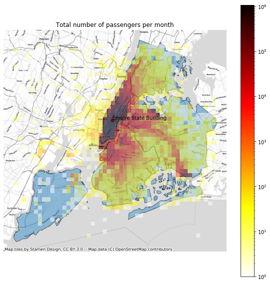

```python
# добавим данные на карту
cmap = mpl.cm.hot_r
norm = mpl.colors.LogNorm(vmin=1, vmax=geo_cell_data.passenger_count_total.max(), clip=True)
(
    geo_cell_data
    .to_crs(epsg=3857)
    .plot(
        column='passenger_count_total',
        legend=True,
        alpha=0.5,
        cmap=cmap,
        figsize=(15, 15),
        norm=norm,
        ax=ax
    )
)

# поменяем подложку, чтобы фон был белым
ctx.add_basemap(ax, url=ctx.providers.Stamen.TonerLite, zoom=12)
ax.set_axis_off()

# добавляем название
plt.title("Total number of passengers per month")
```

#### 4.

Вставьте интерактивную карту Нью-Йорка — такую, которую можно прокручивать и увеличивать. Поставьте метку там, где находится статуя свободы.

```python
# добавляем интерактивную карту
interactive_map = folium.Map(
    location=[40.693943, -73.985880],
    tiles='OpenStreetMap',
    control_scale=True,
    zoom_start=10
)

# ставим метку со статуей Свободы
#sl_location = geopandas.tools.geocode('The Statue of Liberty')
folium.Marker(
    [sl_location.geometry.y[0], sl_location.geometry.x[0]],
    popup='The Statue of Liberty',
    name='The Statue of Liberty'
).add_to(interactive_map)

# отображаем карту
interactive_map
```

[interactive chart not shown]

#### 5.

Нарисуйте на интерактивной карте Нью-Йорка ячейки так, чтобы их цвет показывал среднее за месяц количество поездок такси в час из этой зоны.

```python
# задаем цветовую шкалу
colorscale = branca.colormap.StepColormap(
    ['white', 'lightblue', 'lightgreen', 'yellow', 'orange', 'red', 'purple'],
    index=[0, 1, 10, 50, 100, 200, 500],
    vmin=0,
    vmax=geo_cell_data.average_trip_ph.max()
)

# рисуем ячейки
folium.GeoJson(
    geo_cell_data,
    name='Average taxi trip per hour',
    style_function=lambda feature: {
        'fillOpacity': 0.7,
        'weight': 0,
        'fillColor': colorscale(feature['properties']['average_trip_ph'])
    }
).add_to(interactive_map)

# отображаем результат
interactive_map
```

[interactive chart not shown]

#### 6.

Чтобы не выбирать из всех 2500 ячеек вручную, отфильтруйте ячейки, из которых в мае совершается в среднем меньше 5 поездок в час. Посчитайте количество оставшихся. Проверьте на карте, что среди этих ячеек нет таких, из которых поездки на самом деле невозможны.

```python
geo_cell_data_filtered = geo_cell_data[geo_cell_data.average_trip_ph>=5]
print('Более 5 поездок в час совершается в {} ячейках'.format(geo_cell_data_filtered.shape[0]))
```

```
Более 5 поездок в час совершается в 102 ячейках
```

```python
# добавляем на карту получившиеся ячейки
folium.GeoJson(
    geo_cell_data_filtered,
    name='Filtered average taxi trip per hour',
    style_function=lambda feature: {
        'fillOpacity': 0.7,
        'weight': 0,
        'fillColor': colorscale(feature['properties']['average_trip_ph'])
    }
).add_to(interactive_map)

# добавляем контроль слоев
folium.LayerControl().add_to(interactive_map)
folium.LayerControl()

# посмотрим, что получилось
interactive_map
```

[interactive chart not shown]

Отключим слой "Average taxi trip per hour", оставив только отфильтрованные данные Судя по карте, наблюдаются некоторые аномалии в районе аэропорта Джона Ф. Кеннеди, а также на юге Манхеттена, в районе острова Governors